# Chapter 5: Exploring Numerical Data

# Overview

- Chapter 5: Exploring numerical data
  - 5.1 Scatterplots for paired data
  - 5.2 Dot plots and the mean
  - 5.3 Histograms and shape
  - 5.4 Variance and standard deviation
  - 5.5 Box plots, quartiles, and the median
  - 5.6 Robust statistics
  - 5.7 Transforming data
  - 5.8 Mapping data

# 5.1 Scatterplots for paired data

## Loan Data

```r
library(tidyverse)
library(openintro)
glimpse(loan50)
```

```
Rows: 50
Columns: 18
$ state                   <fct> NJ, CA, SC, CA, OH, IN, NY, MO, FL, FL, MD, HI, CT, NE, CA, TX, HI…
$ emp_length              <dbl> 3, 10, NA, 0, 4, 6, 2, 10, 6, 3, 8, 10, 10, 2, 5, 2, 5, 3, 3, 10, …
$ term                    <dbl> 60, 36, 36, 36, 60, 36, 36, 36, 60, 60, 36, 36, 36, 36, 36, 60, 60…
$ homeownership           <fct> rent, rent, mortgage, rent, mortgage, mortgage, rent, mortgage, re…
$ annual_income           <dbl> 59000, 60000, 75000, 75000, 254000, 67000, 28800, 80000, 34000, 80…
$ verified_income         <fct> Not Verified, Not Verified, Verified, Not Verified, Not Verified, …
$ debt_to_income          <dbl> 0.55752542, 1.30568333, 1.05628000, 0.57434667, 0.23814961, 1.0770…
$ total_credit_limit      <int> 95131, 51929, 301373, 59890, 422619, 349825, 15980, 258439, 87705,…
$ total_credit_utilized   <int> 32894, 78341, 79221, 43076, 60490, 72162, 2872, 28073, 23715, 3203…
$ num_cc_carrying_balance <int> 8, 2, 14, 10, 2, 4, 1, 3, 10, 4, 3, 4, 3, 2, 3, 6, 5, 4, 5, 10, 1,…
$ loan_purpose            <fct> debt_consolidation, credit_card, debt_consolidation, credit_card, …
$ loan_amount             <int> 22000, 6000, 25000, 6000, 25000, 6400, 3000, 14500, 10000, 18500, …
$ grade                   <fct> B, B, E, B, B, B, D, A, A, C, D, A, A, A, A, E, D, B, A, D, C, D, …
$ interest_rate           <dbl> 10.90, 9.92, 26.30, 9.92, 9.43, 9.92, 17.09, 6.08, 7.97, 12.62, 17…
$ public_record_bankrupt  <int> 0, 1, 0, 0, 0, 0, 0, 0, 0, 1, 0, 0, 0, 0, 0, 0, 0, 0, 0, 0, 0, 0, …
$ loan_status             <fct> Current, Current, Current, Current, Current, Current, Current, Cur…
$ has_second_income       <lgl> FALSE, FALSE, FALSE, FALSE, FALSE, FALSE, FALSE, FALSE, FALSE, TRU…
$ total_income            <dbl> 59000, 60000, 75000, 75000, 254000, 67000, 28800, 80000, 34000, 19…
```

## Scatterplot of amount vs. income

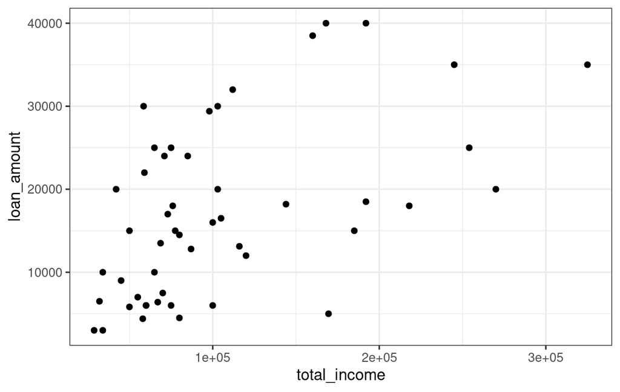

```r
loan50 %>%
  ggplot(aes(x = total_income, y = loan_amount)) +
  geom_point()
```

## County Data

```r
glimpse(county)
```

```
Rows: 3,142
Columns: 15
$ name              <chr> "Autauga County", "Baldwin County", "Barbour County", "Bibb County", "Bl…
$ state             <fct> Alabama, Alabama, Alabama, Alabama, Alabama, Alabama, Alabama, Alabama, …
$ pop2000           <dbl> 43671, 140415, 29038, 20826, 51024, 11714, 21399, 112249, 36583, 23988, …
$ pop2010           <dbl> 54571, 182265, 27457, 22915, 57322, 10914, 20947, 118572, 34215, 25989, …
$ pop2017           <int> 55504, 212628, 25270, 22668, 58013, 10309, 19825, 114728, 33713, 25857, …
$ pop_change        <dbl> 1.48, 9.19, -6.22, 0.73, 0.68, -2.28, -2.69, -1.51, -1.20, -0.60, 0.97, …
$ poverty           <dbl> 13.7, 11.8, 27.2, 15.2, 15.6, 28.5, 24.4, 18.6, 18.8, 16.1, 19.4, 22.3, …
$ homeownership     <dbl> 77.5, 76.7, 68.0, 82.9, 82.0, 76.9, 69.0, 70.7, 71.4, 77.5, 75.1, 85.6, …
$ multi_unit        <dbl> 7.2, 22.6, 11.1, 6.6, 3.7, 9.9, 13.7, 14.3, 8.7, 4.3, 4.4, 3.9, 6.3, 11.…
$ unemployment_rate <dbl> 3.86, 3.99, 5.90, 4.39, 4.02, 4.93, 5.49, 4.93, 4.08, 4.05, 4.05, 6.39, …
$ metro             <fct> yes, yes, no, yes, yes, no, no, yes, no, no, yes, no, no, no, no, no, ye…
$ median_edu        <fct> some_college, some_college, hs_diploma, hs_diploma, hs_diploma, hs_diplo…
$ per_capita_income <dbl> 27841.70, 27779.85, 17891.73, 20572.05, 21367.39, 15444.16, 17014.95, 23…
$ median_hh_income  <int> 55317, 52562, 33368, 43404, 47412, 29655, 36326, 43686, 37342, 40041, 43…
$ smoking_ban       <fct> none, none, partial, none, none, none, NA, NA, none, none, none, none, n…
```

## Scatterplot of income vs poverty rate

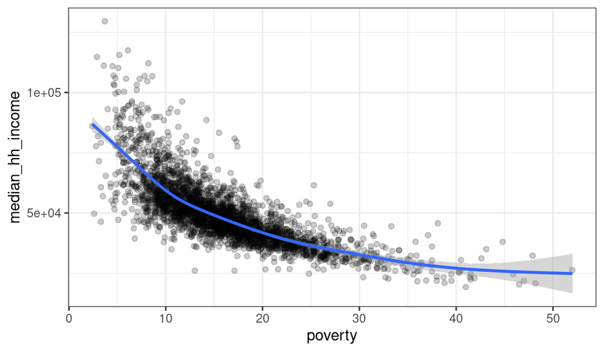

```r
county %>%
  ggplot(aes(x = poverty, y = median_hh_income)) +
  geom_point(alpha = 0.2) +
  geom_smooth()
```

# 5.2 Dot plots and the mean

## One Quantitative Variable

A **dot plot** is a quick way to understand the distribution of a single quantitative variable.

```r
loan50$interest_rate
```

```
 [1] 10.90  9.92 26.30  9.92  9.43  9.92 17.09  6.08  7.97 12.62 17.09  5.31  7.35  5.31  7.96 24.85
[17] 18.06 10.42  7.96 19.42 14.08 20.00  9.44  9.92 10.91  5.32  6.71 15.04 11.98 12.62 10.91  9.44
[33]  9.93  7.35 18.45 17.09  7.96  6.08  6.71  7.34 12.62 16.02 10.90  9.93  9.44 10.42 21.45 10.91
[49]  9.43  6.08
```

## Dot Plot of interest rate

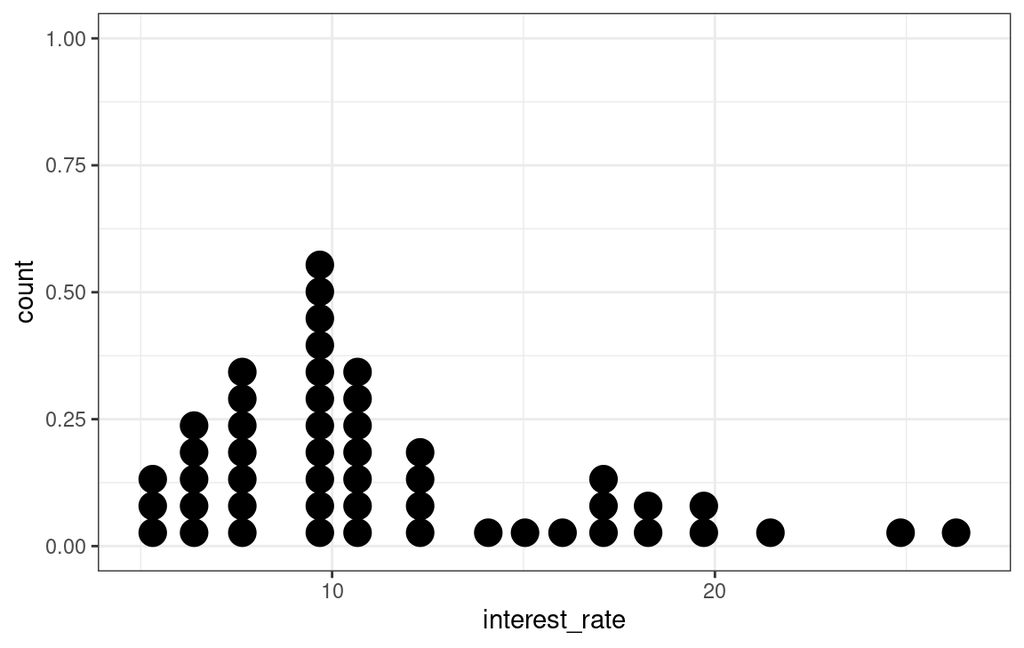

```r
loan50 %>%
  ggplot(aes(x = interest_rate)) +
  geom_dotplot()
```

## Sample Mean

The **sample mean** $\bar{x}$ is the sum of the values divided by the number of observations.

- The sample mean is a *statistic*.

$$\bar{x} = \frac{x_1 + x_2 + \cdots + x_n}{n}$$

```r
mean(loan50$interest_rate)
```

```
[1] 11.5672
```

## Population Mean

- The `loan50` data set is a *sample* from a much larger *population* of loans.
- The **population mean** is the average of all values in the population.
  - The population mean is a *parameter*.
  - Parameters are generally unknown, but we estimate them with statistics.
    - Our best guess *point estimate* for the population mean interest rate is the sample mean (11.5672).
  - We use the symbol $\mu$ (the Greek letter mu) for the population mean.

## Group Exercise

1. In the dot plot below, pretend that the dots are all physical objects (e.g., weights), and that the horizontal axis is a plank of wood. Where on the plank of wood would you place a support (i.e., fulcrum) so that the whole structure will balance?

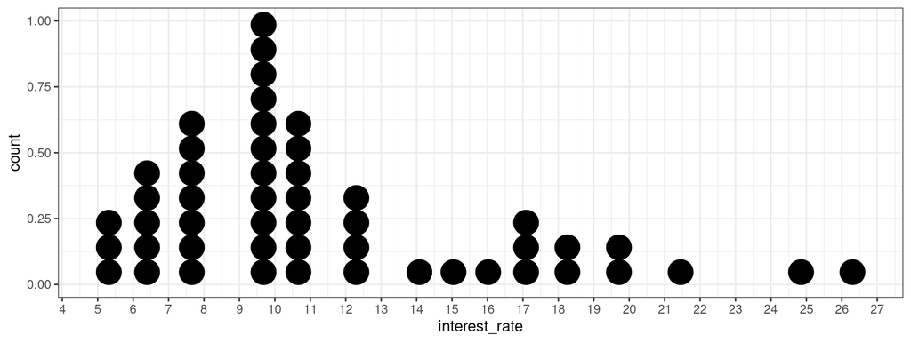

# 5.3 Histograms and shape

## Histograms

- A **histogram** is a bar plot where each bar shows the number of values that fall in its interval.
- Like dot plots, histograms show how a variable is distributed.

## Histogram of interest rate

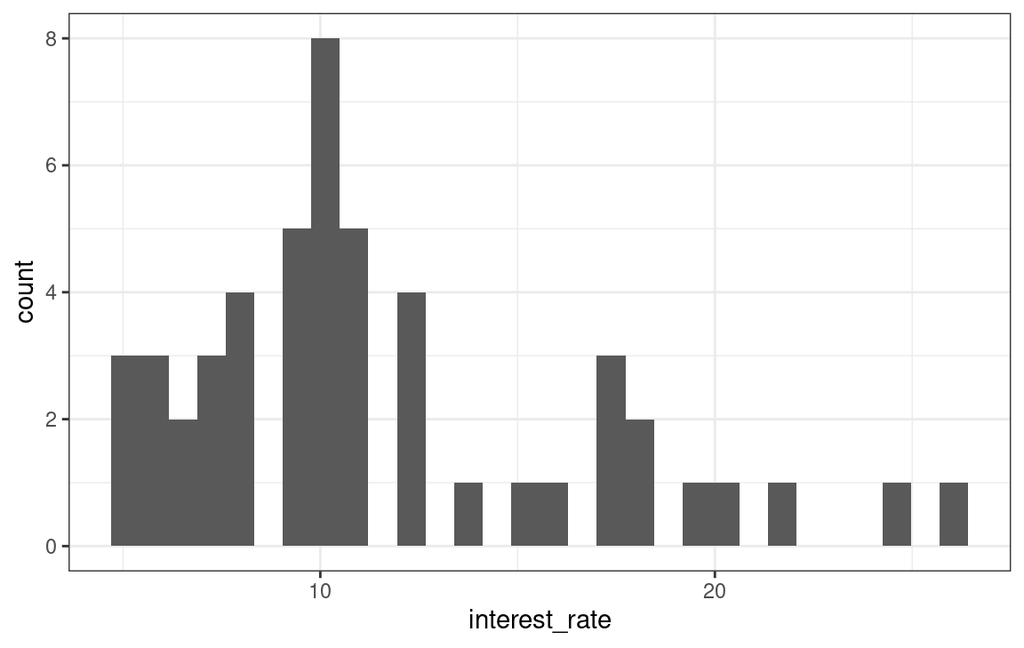

```r
loan50 %>%
  ggplot(aes(x = interest_rate)) +
  geom_histogram()
```

## Histogram of interest rate

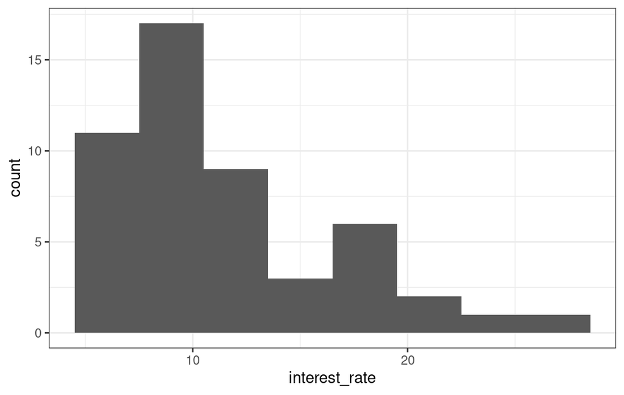

```r
loan50 %>%
  ggplot(aes(x = interest_rate)) +
  geom_histogram(binwidth = 3)
```

## Density plot of interest rate

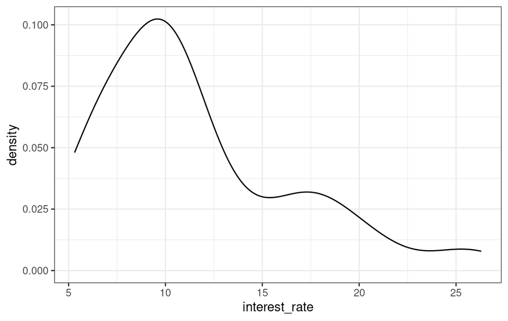

```r
loan50 %>%
  ggplot(aes(x = interest_rate)) +
  geom_density()
```

## Density plot of interest rate

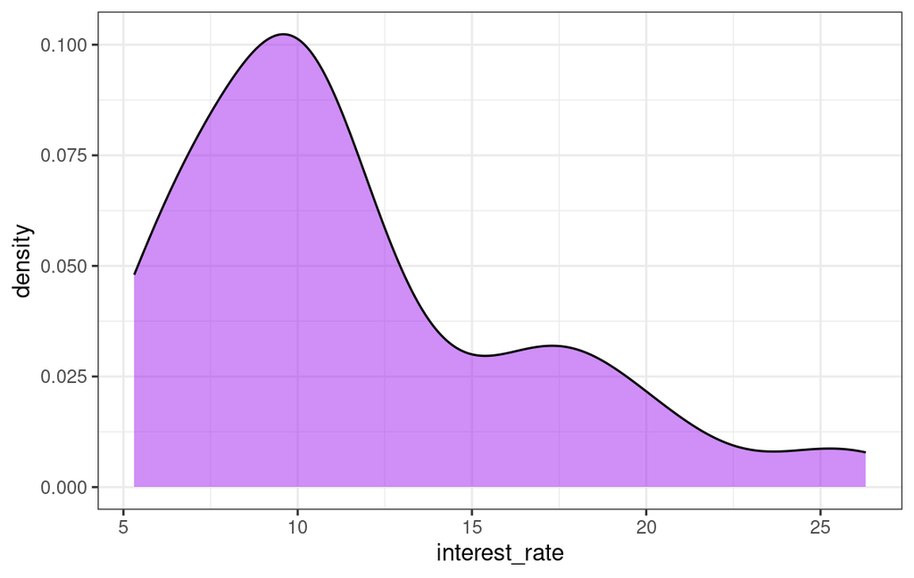

```r
loan50 %>%
  ggplot(aes(x = interest_rate)) +
  geom_density(fill = "purple", alpha = 0.5)
```

## Skew

This density plot has a longer *tail* on the right.

- If a distribution has a longer tail on the right, it is called **skewed right**.
- If a distribution has a longer tail on the left, it is called **skewed left**.
- It the two tails are the same, the distribution is **symmetric**.

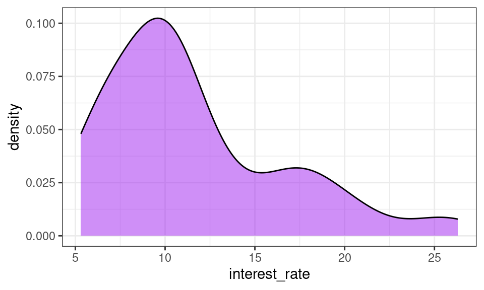

## Group Discussion

1. Why would interest rates be skewed right? What sort of loans would be in the right tail? What sort of borrowers would take out such a loan?
2. Estimate a range of interest rates that captures 50% of the loans in this sample.
3. What is the most common interest rate in this sample?

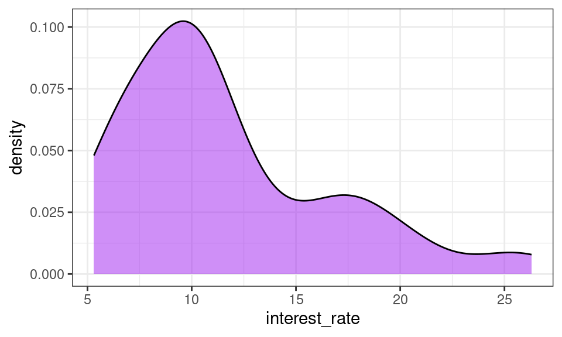

# 5.4 Variance and standard deviation

## Sample Variance

- The **variance** of a sample is the average squared distance from the mean.
- The **sample standard deviation** is the square root of the sample variance.

$$s = \sqrt{\frac{\sum_{i=1}^n (x_i - \bar{x})^2}{n-1}}$$

Standard deviation gives a measure of *how spread out* the data are.

- We use $s$ for the sample standard deviation, so $s^2$ is the sample variance.
- We use $\sigma$ (the Greek letter sigma) for the population standard deviation, so $\sigma^2$ is the population variance.

## Big and small standard deviation

Smaller standard deviation

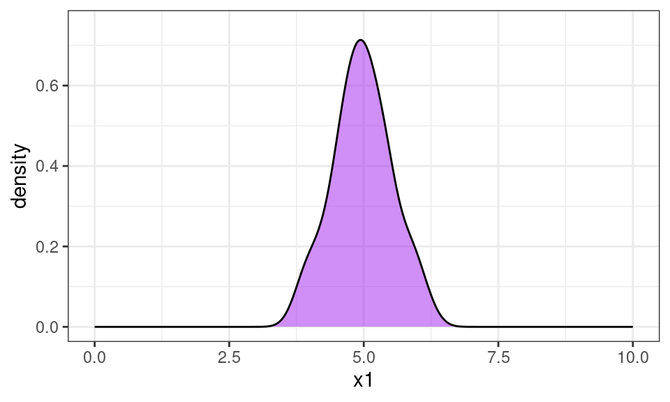

Bigger standard deviation

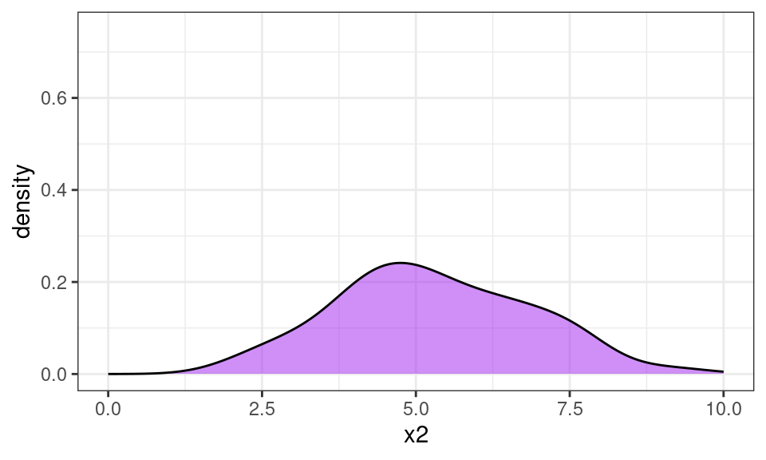

# 5.5 Box plots, quartiles, and the median

## Group Activity

Consider the following ordered list of 50 interest rates.

```
 rate1  rate2  rate3  rate4  rate5  rate6  rate7  rate8  rate9 rate10 rate11 rate12
   5.3    5.3    5.3    6.1    6.1    6.1    6.7    6.7    7.3    7.3    7.3    8.0
rate13 rate14 rate15 rate16 rate17 rate18 rate19 rate20 rate21 rate22 rate23 rate24
   8.0    8.0    8.0    9.4    9.4    9.4    9.4    9.4    9.9    9.9    9.9    9.9
rate25 rate26 rate27 rate28 rate29 rate30 rate31 rate32 rate33 rate34 rate35 rate36
   9.9    9.9   10.4   10.4   10.9   10.9   10.9   10.9   10.9   12.0   12.6   12.6
rate37 rate38 rate39 rate40 rate41 rate42 rate43 rate44 rate45 rate46 rate47 rate48
  12.6   14.1   15.0   16.0   17.1   17.1   17.1   18.1   18.4   19.4   20.0   21.4
rate49 rate50
  24.9   26.3
```

1. Estimate the **median** interest rate. (The median is the middle value.)
2. Estimate the **first quartile**. The first quartile is the 25th percentile, i.e., the value below which 25% of the data lies.
3. Estimate the **third quartile** (i.e., the 75th percentile).

## Five-number summary

```r
summary(rates)
```

```
   Min. 1st Qu.  Median    Mean 3rd Qu.    Max.
   5.30    8.00    9.90   11.56   13.72   26.30
```

## Box Plots

A *box plot* shows a box that covers the range of the middle 50% of the data.

- The edges of the box are the 25th and 75th percentiles (i.e., first and third *quartiles*).
  - The distance between these edges is the *inter-quartile range* (IQR).
- The line in the middle of the box is the median (50th percentile).
- The whiskers show the range of the data.

## Box plots and variability

Smaller standard deviation

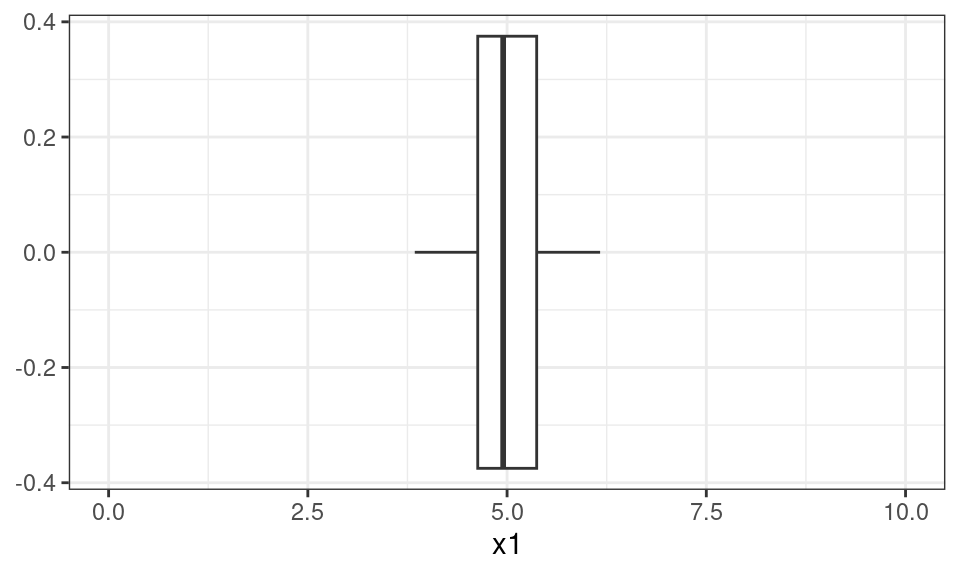

Bigger standard deviation

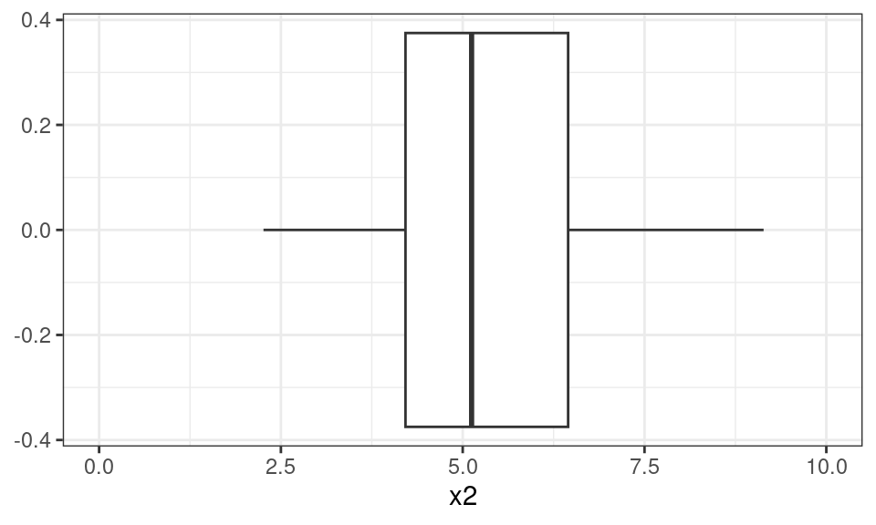

## Box plots and variability

Smaller standard deviation

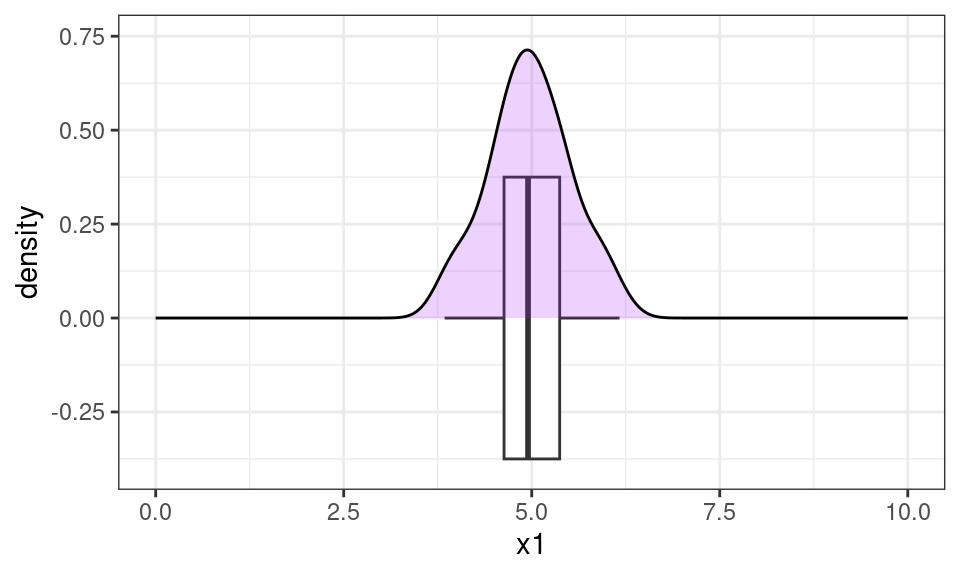

Bigger standard deviation

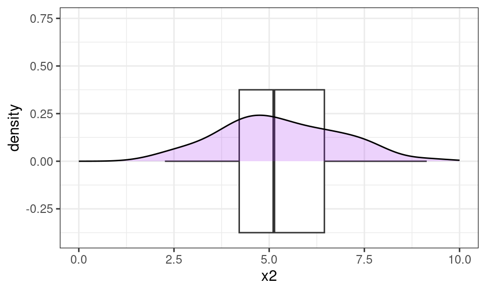

# 5.6 Robust statistics

## Robustness

A statistic is called *robust* if it’s value stays more-or-less the same when one or two data points change.

## Robust or not?

| Scenario | Median | IQR | Mean | SD |
| --- | --- | --- | --- | --- |
| Original data | 9.93 | 5.755 | 11.5672 | 5.052115 |
| Move 26.3% to 15% | 9.93 | 5.755 | 11.3412 | 4.613300 |
| Move 26.3% to 35% | 9.93 | 5.755 | 11.7412 | 5.680608 |

- The *median* (i.e., the middle value) and the *IQR* are robust.
- The *mean* and *standard deviation* are not robust.

## Group Discussion

1. When realtors report the housing prices in an area, they usually report the median, rather than the mean. Why do you think they do that?
2. When professors compute final grades for a course, they usually compute the mean of all your test scores, rather than the median. Why do you think they do that?

# 4.6 (last time) Comparing numerical data across groups

- *Explanatory variable:* categorical
- *Response variable:* numeric

## Example: teaching evaluations

```r
glimpse(evals)
```

```
Rows: 463
Columns: 23
$ course_id     <int> 1, 2, 3, 4, 5, 6, 7, 8, 9, 10, 11, 12, 13, 14, 15, 16, 17, 18, 19,…
$ prof_id       <int> 1, 1, 1, 1, 2, 2, 2, 3, 3, 4, 4, 4, 4, 4, 4, 4, 4, 5, 5, 5, 5, 5, …
$ score         <dbl> 4.7, 4.1, 3.9, 4.8, 4.6, 4.3, 2.8, 4.1, 3.4, 4.5, 3.8, 4.5, 4.6, 3…
$ rank          <fct> tenure track, tenure track, tenure track, tenure track, tenured, t…
$ ethnicity     <fct> minority, minority, minority, minority, not minority, not minority…
$ gender        <fct> female, female, female, female, male, male, male, male, male, fema…
$ language      <fct> english, english, english, english, english, english, english, eng…
$ age           <int> 36, 36, 36, 36, 59, 59, 59, 51, 51, 40, 40, 40, 40, 40, 40, 40, 40…
$ cls_perc_eval <dbl> 55.81395, 68.80000, 60.80000, 62.60163, 85.00000, 87.50000, 88.636…
$ cls_did_eval  <int> 24, 86, 76, 77, 17, 35, 39, 55, 111, 40, 24, 24, 17, 14, 37, 18, 1…
$ cls_students  <int> 43, 125, 125, 123, 20, 40, 44, 55, 195, 46, 27, 25, 20, 25, 42, 20…
$ cls_level     <fct> upper, upper, upper, upper, upper, upper, upper, upper, upper, upp…
$ cls_profs     <fct> single, single, single, single, multiple, multiple, multiple, sing…
$ cls_credits   <fct> multi credit, multi credit, multi credit, multi credit, multi cred…
$ bty_f1lower   <int> 5, 5, 5, 5, 4, 4, 4, 5, 5, 2, 2, 2, 2, 2, 2, 2, 2, 7, 7, 7, 7, 7, …
$ bty_f1upper   <int> 7, 7, 7, 7, 4, 4, 4, 2, 2, 5, 5, 5, 5, 5, 5, 5, 5, 9, 9, 9, 9, 9, …
$ bty_f2upper   <int> 6, 6, 6, 6, 2, 2, 2, 5, 5, 4, 4, 4, 4, 4, 4, 4, 4, 9, 9, 9, 9, 9, …
$ bty_m1lower   <int> 2, 2, 2, 2, 2, 2, 2, 2, 2, 3, 3, 3, 3, 3, 3, 3, 3, 7, 7, 7, 7, 7, …
$ bty_m1upper   <int> 4, 4, 4, 4, 3, 3, 3, 3, 3, 3, 3, 3, 3, 3, 3, 3, 3, 6, 6, 6, 6, 6, …
$ bty_m2upper   <int> 6, 6, 6, 6, 3, 3, 3, 3, 3, 2, 2, 2, 2, 2, 2, 2, 2, 6, 6, 6, 6, 6, …
$ bty_avg       <dbl> 5.000, 5.000, 5.000, 5.000, 3.000, 3.000, 3.000, 3.333, 3.333, 3.1…
$ pic_outfit    <fct> not formal, not formal, not formal, not formal, not formal, not fo…
$ pic_color     <fct> color, color, color, color, color, color, color, color, color, col…
```

## Group by gender and summarize

Do men get higher teaching evaluations than women?

```r
evals %>%
  group_by(gender) %>%
  summarize(ave_eval = mean(score))
```

```
# A tibble: 2 × 2
  gender ave_eval
  <fct>     <dbl>
1 female     4.09
2 male       4.23
```

## Side-by-side Boxplots

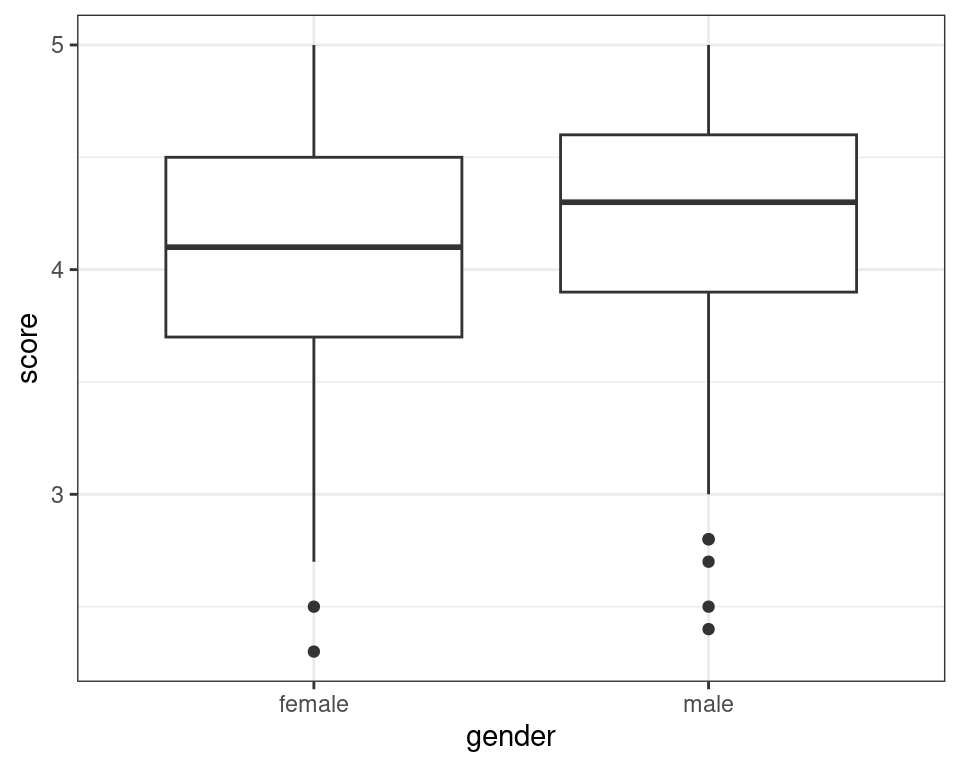

```r
evals %>%
  ggplot(aes(x = gender, y = score)) +
  geom_boxplot()
```

## Side-by-side Boxplots (horizontal)

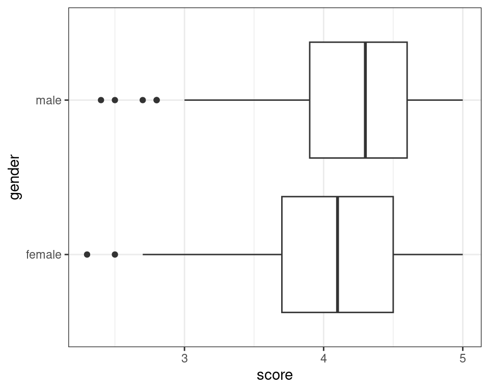

```r
evals %>%
  ggplot(aes(x = score, y = gender)) +
  geom_boxplot()
```

## Histograms

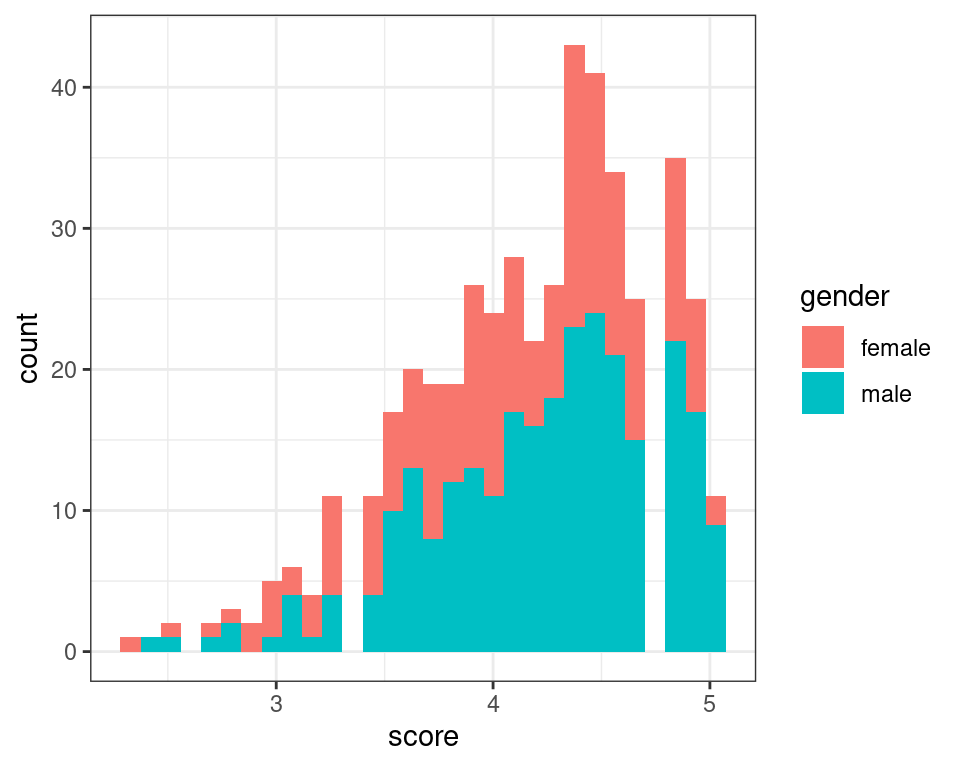

```r
evals %>%
  ggplot(aes(x = score, fill = gender)) +
  geom_histogram()
```

## Dodged Histograms

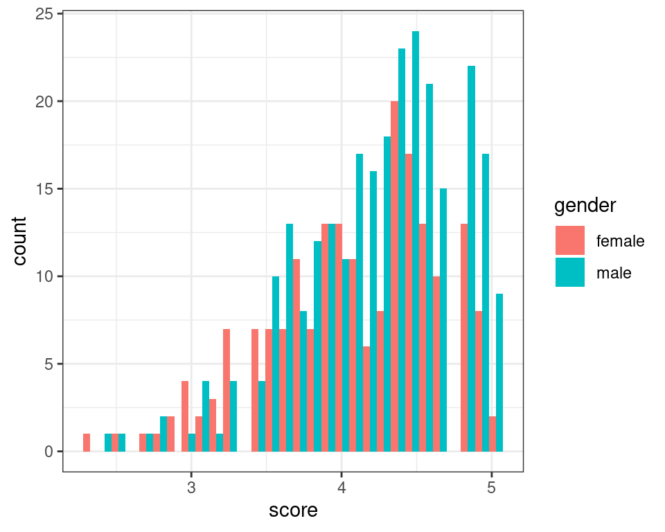

```r
evals %>%
  ggplot(aes(x = score, fill = gender)) +
  geom_histogram(position = "dodge")
```

## Density Plots

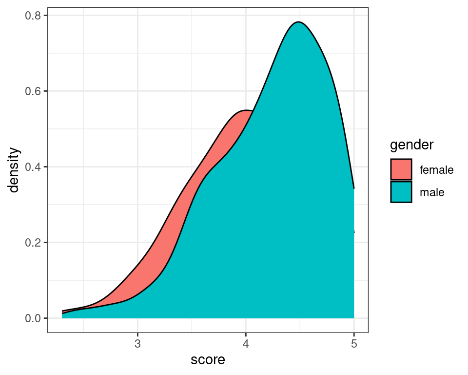

```r
evals %>%
  ggplot(aes(x = score, fill = gender)) +
  geom_density()
```

## Density Plots

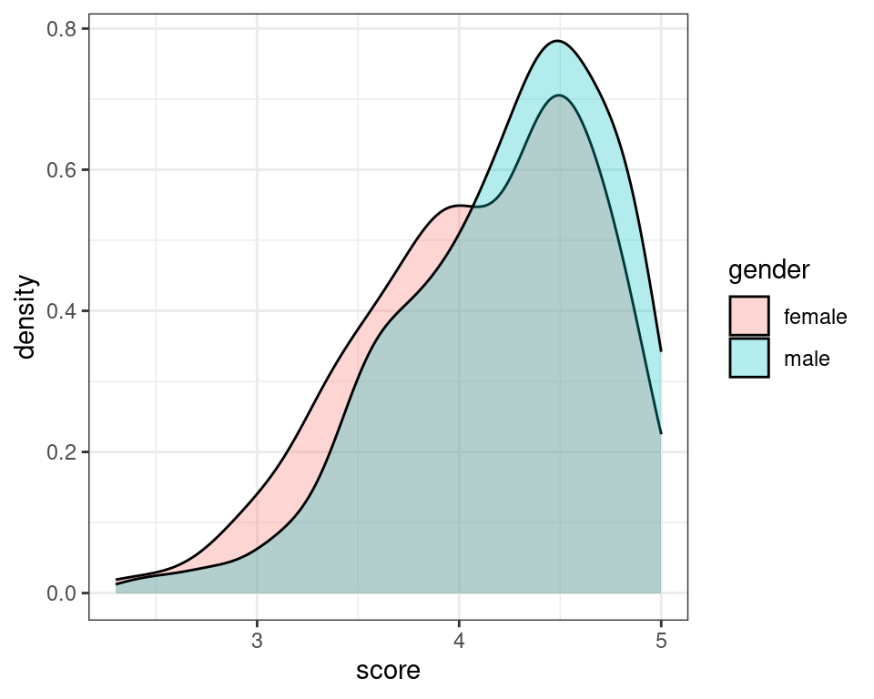

```r
evals %>%
  ggplot(aes(x = score, fill = gender)) +
  geom_density(alpha = 0.3)
```

## Ridge Plots

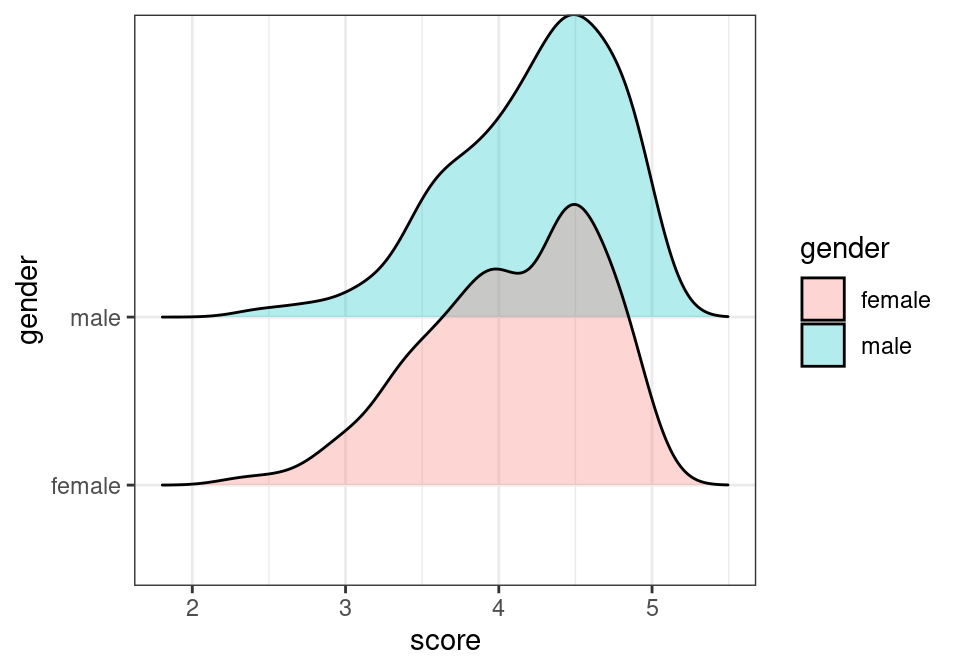

```r
library(ggridges)
evals %>%
  ggplot(aes(x = score, y = gender, fill = gender)) +
  geom_density_ridges(alpha = 0.3)
```